# Recruitment DFA data processing

Robert Wildermuth

2025-02-05

Documentation of data processing for Dynamic Factor Analysis of sardine recruitment indicators. Data are updated to cover through 2023 or later. Indicators directly relevant to anchovy have been removed.

```r
# Copied from https://github.com/futureseas/recrmntDFA 1/14/2025

library(tidyverse)
library(MARSS)
library(lubridate)
library(sf)
library(stars)
library(cubelyr)
library(r4ss)
library(units)
```

# California Current Integrated Ecosystem Assessment data

Data were downloaded from the [CalCurrent IEA website](https://www.integratedecosystemassessment.noaa.gov/regions/california-current/california-current-iea-indicators) 1/16/2025. Monthly or seasonal values were aggregated across relevant time periods for fish life histories to create annual values for the DFA.

```r
# get data files to read in and collate

# data file path
datPath <- "C:/Users/r.wildermuth/Documents/CEFI/SardineRecruitmentESP/DFA_data/"
# handle weights, habitat, and zooplankton separately
datFiles <- list.files(datPath)
datFiles <- grep("cciea_", datFiles, fixed = TRUE, value = TRUE)

# use updated time series
datFiles <- datFiles[which(!grepl("2023", datFiles))]

# df names
datNames <- sub("_dl20250116.csv", "", datFiles)
datNames <- sub("_dl20250325.csv", "", datNames)
datNames <- sub("cciea_", "", datNames)

# -------- Create table mapping variable names to descriptions and sources -----
datDict <- data.frame(Variable = datNames,
                      Description = c(
                                      "Northern copepod biomass anomaly at 44.6N",
                                      "Southern copepod biomass anomaly at 44.6N",
                                      "Biologically Effective Upwelling Transport Index at 33N",
                                      "Biologically Effective Upwelling Transport Index at 39N",
                                      "Coastal Upwelling Transport Index at 33N",
                                      "Coastal Upwelling Transport Index at 39N",
                                      "Habitat compression index 30N to 35.5N",
                                      # "Habitat compression index 35.5N to 40N",
                                      "Length of Upwelling Season Index at 33N",
                                      "Length of Upwelling Season Index at 36N",
                                      "Length of Upwelling Season Index at 39N",
                                      "Spring Transition Index at 33N",
                                      "Spring Transition Index at 36N",
                                      "Spring Transition Index at 39N",
                                      "Mean myctophids in SWFSC Rockfish Recruitment & Ecosystem Assessment Survey (log(CPUE+1))",
                                      "Young-of-the-year sardine in SWFSC Rockfish Recruitment & Ecosystem Assessment Survey",
                                      "Total spring CalCOFI larval sardine (ln(n+1)/10m^2)",
                                      "Total spring CalCOFI larval southern mesopelagics (ln(n+1)/10m^2)"),
                      Source = "CCIEA")
datDict
```

```
##                      Variable
## 1        EI_NorthernCOP_44.6N
## 2        EI_SouthernCOP_44.6N
## 3                OC_BEUTI_33N
## 4                OC_BEUTI_39N
## 5                 OC_CUTI_33N
## 6                 OC_CUTI_39N
## 7              OC_HCI_30N355N
## 8                 OC_LUSI_33N
## 9                 OC_LUSI_36N
## 10                OC_LUSI_39N
## 11                 OC_STI_33N
## 12                 OC_STI_36N
## 13                 OC_STI_39N
## 14           RREAS_Myctophids
```

[output cut: 39 more lines]

```r
for(i in 1:length(datFiles)) {
  assign(datNames[i],
         read_csv(paste0(datPath,
                          datFiles[i]),
                  col_names = c("time", datNames[i]),
                  col_types = c("T","d"),
                  skip = 2))
}


# creates 'year' and 'month' columns
recrDat <- lapply(mget(datNames),
                  function(x) {x %>% mutate(year = year(time),
                                            month = month(time)) %>%
                                  select(-time)})

# Read in SSWI separately
sswi <- read_csv(file.path(datPath, "sswi_monthly_35-37N_1980-2010.csv"))
# # ---- Aggregate monthly measures for annual time series ------
# # NPGO indicator of forage, aggregate May - July
# recrDat$OC_NPGO <- recrDat$OC_NPGO %>% filter(month %in% 5:7) %>%
#                       group_by(year) %>%
#                       summarize(NPGO = mean(OC_NPGO))
#
# # PDO indicator of preconditioning, aggregate March - July, Aug - Oct
# recrDat$OC_PDO <- recrDat$OC_PDO %>% filter(month %in% 3:10) %>%
#                       mutate(seas = case_when(month %in% 3:7 ~ "spring",
#                                               month %in% 8:10 ~ "summer")) %>%
#                       group_by(year, seas) %>%
#                       summarize(PDO = mean(OC_PDO)) %>%
#                       pivot_wider(names_from = seas, names_prefix = "PDO",
#                                   values_from = PDO)
#
# # NOI indicator of forage, aggregate March - July
# recrDat$OC_NOI <- recrDat$OC_NOI %>% filter(month %in% 3:7) %>%
#                       group_by(year) %>%
#                       summarize(NOI = mean(OC_NOI))
#
# # ENSO indicator of forage, aggregate March - July
# recrDat$OC_MultiENSOindx <- recrDat$OC_MultiENSOindx %>% filter(month %in% 3:7) %>%
#                               group_by(year) %>%
#                               summarize(ENSO = mean(OC_MultiENSOindx))

# BEUTI indicator of forage, aggregate May - July
recrDat$OC_BEUTI_33N <- recrDat$OC_BEUTI_33N %>% filter(month %in% 5:7) %>%
                          group_by(year) %>%
                          summarize(BEUTI_33N = mean(OC_BEUTI_33N))
recrDat$OC_BEUTI_39N <- recrDat$OC_BEUTI_39N %>% filter(month %in% 5:7) %>%
                          group_by(year) %>%
                          summarize(BEUTI_39N = mean(OC_BEUTI_39N))

# CUTI indicator of forage, aggregate May - July
recrDat$OC_CUTI_33N <- recrDat$OC_CUTI_33N %>% filter(month %in% 5:7) %>%
                          group_by(year) %>%
                          summarize(CUTI_33N = mean(OC_CUTI_33N))
recrDat$OC_CUTI_39N <- recrDat$OC_CUTI_39N %>% filter(month %in% 5:7) %>%
                          group_by(year) %>%
                          summarize(CUTI_39N = mean(OC_CUTI_39N))

# HCI indicator of preconditioning, aggregate Feb - July
recrDat$OC_HCI_30N355N <- recrDat$OC_HCI_30N355N %>% filter(month %in% 2:7) %>%
                              group_by(year) %>%
                              summarize(HCI_30N355N = mean(OC_HCI_30N355N)) # Region 3

# recrDat$EI_HCI_355N40N <- recrDat$EI_HCI_355N40N %>% filter(month %in% 2:7) %>%
#                               group_by(year) %>%
#                               summarize(HCI_R4 = mean(EI_HCI_355N40N)) # Region 4

# COPepod community indicator of preconditioning and forage, aggregate March - July, Aug - Oct
recrDat$EI_NorthernCOP_44.6N <- recrDat$EI_NorthernCOP_44.6N %>% filter(month %in% 3:10) %>%
                      mutate(seas = case_when(month %in% 3:7 ~ "spring",
                                              month %in% 8:10 ~ "summer")) %>%
                      group_by(year, seas) %>%
                      summarize(NCOP = mean(EI_NorthernCOP_44.6N)) %>%
                      pivot_wider(names_from = seas, names_prefix = "NCOP",
                                  values_from = NCOP)
# lag summer zooplankton for condition
recrDat$EI_NorthernCOP_44.6N$NCOPsummerlag1 <- lag(recrDat$EI_NorthernCOP_44.6N$NCOPsummer, n=1)


recrDat$EI_SouthernCOP_44.6N <- recrDat$EI_SouthernCOP_44.6N %>% filter(month %in% 3:10) %>%
                      mutate(seas = case_when(month %in% 3:7 ~ "spring",
                                              month %in% 8:10 ~ "summer")) %>%
                      group_by(year, seas) %>%
                      summarize(SCOP = mean(EI_SouthernCOP_44.6N)) %>%
                      pivot_wider(names_from = seas, names_prefix = "SCOP",
                                  values_from = SCOP)
# lag summer zooplankton for condition
recrDat$EI_SouthernCOP_44.6N$SCOPsummerlag1 <- lag(recrDat$EI_SouthernCOP_44.6N$SCOPsummer, n=1)

# Southern Source Water Index indicator of nursery habitat, aggregate Jan-Jun, Jul-Dec
# From Mike Jacox (5/15/2023): "The way I did these runs was similar to particle tracking, but a different methodology that relies on the internal workings of the ROMS code. In effect, you can think of it like adding a dye or tracer to an area of the ocean and then tracking it backward in time."
sswi <- sswi %>% mutate(seas = case_when(month %in% 1:6 ~ "spring",
                                         month %in% 7:12 ~ "summer")) %>%
          group_by(year, seas) %>%
          summarize(avgSSWI = mean(sswi)) %>%
          pivot_wider(names_from = seas, names_prefix = "avgSSWI",
                      values_from = avgSSWI)
```

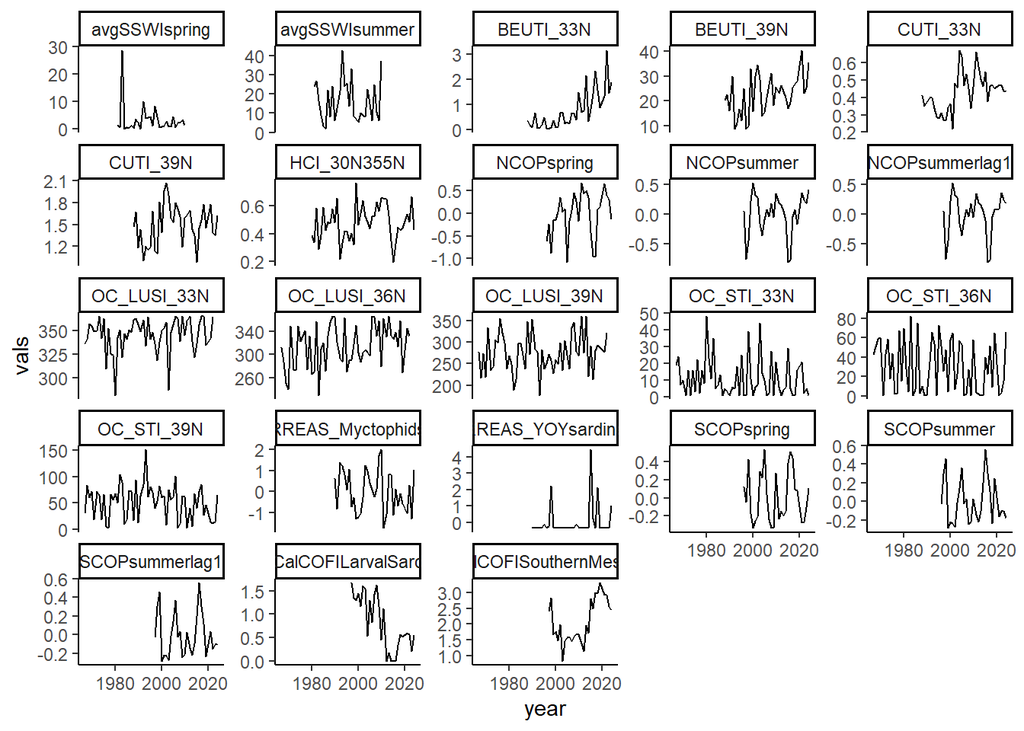

```r
# collapses dfs into single wide table
recrDat <- recrDat %>% reduce(full_join, by = "year")
recrDat <- recrDat %>% select(-starts_with("month", vars = names(recrDat))) %>%
              arrange(year)
recrDat <- recrDat %>% full_join(y = sswi, by = "year")

recrDat %>% pivot_longer(cols = c(-year), names_to = "Index", values_to = "vals") %>%
  filter(!is.na(vals), year >= 1950, year != 2020) %>%
  ggplot(aes(x = year, y = vals)) +
  geom_line() +
  facet_wrap(~Index, scales = "free_y") +
  theme_classic()
```

# Other oceanographic indices

```r
# From Mer Pozo Buil (6/4/2023): "monthly SST averaged for the diagonal CalCOFI region for the 3 datasets:
# ROMS-ESMS: includes the 3 projections (ROMS-GFDL, ROMS-IPSL, and ROMS-HAD) from 1980-2100
# WCRNT: includes ROMS real-near time from 2011-Oct2022
# WCRA: includes ROMS reanalysis from 1980-2010"
WCRNT <- read_csv(paste0(datPath, "WCNRT_CalCOFI_monave_SST_201101_202210.csv"))
WCRNT <- WCRNT %>% mutate(seas = case_when(month %in% 1:6 ~ "spring",
                                         month %in% 7:12 ~ "summer")) %>%
                      group_by(year, seas) %>%
                      summarize(SSTwcnrt = mean(sst_wcnrt)) %>%
                      pivot_wider(names_from = seas, names_prefix = "SSTwcnrt",
                                  values_from = SSTwcnrt)
# # Read updated NRT dataset and aggregate to monthly time series similar to Mer
# # Downloaded from Mike Jacox (2/12/2025)
# WCNRT <- read_stars(paste0(datPath, "wcnrt_sst_daily_20110102_20240630.nc"),
#                     sub = 3, curvilinear = c("lon_rho", "lat_rho"), proxy = FALSE)
# WCNRT <- st_transform(WCNRT, crs = st_crs("+proj=longlat +ellps=WGS84 +datum=WGS84"))
#
# # Create bounding box for CalCOFI grid used by Mer (email from 3/24/2025)
# # Most northern, southern, western and eastern stations, respectively:
# # line/station 76.7,49,
# calCOFIstations <- matrix(c(35.0884327672,-120.77761231,
# # line/station 93.3,120,
#                             29.8460905906,-123.586475114,
# # line/station 93.3,120,
#                             29.8460905906,-123.586475114,
# # line/station 93.3,28,
#                             32.9087913558,-117.385498462,
# # Diagonals
#                             35.0250407188,-120.926385792,
#                              34.8935364583,-121.206645213,
#                              34.723639335,-121.553587787,
#                              34.3918126902,-122.251790429,
#                              34.0583872874,-122.942745523,
#                              33.7214985322,-123.635665298,
#                              32.8405611621,-117.526354339,
#                              32.6799104261,-117.872482381,
#                              32.5072812543,-118.207431003,
#                              32.3485483889,-118.557107667,
#                              32.1762365645,-118.889031952,
#                              32.0121154898,-119.234211524,
#                              31.8390928456,-119.571038136,
#                              31.5064951255,-120.246149557,
#                              31.1716012973,-120.917256938,
#                              30.8417498299,-121.586797921,
#                              30.5142659565,-122.251707266,
#                              30.1820846918,-122.923195089),
#                           ncol = 2, byrow = TRUE)
# calCOFIstations <- as.data.frame(calCOFIstations) %>% rename("lat" = "V1",
#                                                              "lon" = "V2")
#
# calCOFIstations <- calCOFIstations %>% st_as_sf(coords = c("lon", "lat")) %>%
#                       summarize(geometry = st_union(geometry)) %>%
#                       st_convex_hull()
# st_crs(calCOFIstations) <- "+proj=longlat +ellps=WGS84 +datum=WGS84"
#
# WCNRTcalCOFI <- st_crop(WCNRT, calCOFIstations)
#
# test1 <-  aggregate(WCNRTcalCOFI, by = "months", FUN = mean)

WCRA <- read_csv(paste0(datPath, "WCRA31_CalCOFI_monave_SST_198001-2010012.csv"))
WCRA <- WCRA %>% mutate(seas = case_when(month %in% 1:6 ~ "spring",
                                         month %in% 7:12 ~ "summer")) %>%
                      group_by(year, seas) %>%
                      summarize(SSTwcra = mean(sst_wcra31)) %>%
                      pivot_wider(names_from = seas, names_prefix = "SSTwcra",
                                  values_from = SSTwcra)
# Northward transport across 32N
# Downloaded from Mike Jacox (8/18/2023)
transportOffshore <- read_ncdf(paste0(datPath, "wcra31_monthly_northward_velocity_0-50m_124.0-120.0W_31.9-32.1N_1981-2010.nc"))
```

```
## no 'var' specified, using year, month, time, v
## Will return stars object with 360 cells.
```

```r
# NRT transport downloaded from Mike Jacox (3/24/2025)
transpNRTOffshore <- read_ncdf(paste0(datPath, "monthly_northward_velocity_wcnrt_0-50m_124.0-120.0W_31.9-32.1N_2011-2024.nc"))
```

```
## no 'var' specified, using year, month, time, v
## Will return stars object with 167 cells.
```

```r
offshoreTrans <- data.frame(year = transportOffshore$year,
                            month = transportOffshore$month,
                            offshTrans = transportOffshore$v)
offTransNRT <- data.frame(year = transpNRTOffshore$year,
                            month = transpNRTOffshore$month,
                            offshTrans = transpNRTOffshore$v)

transport <- bind_rows(offshoreTrans, offTransNRT) %>%
                mutate(seas = case_when(month %in% 1:6 ~ "spring",
                                          month %in% 6:12 ~ "summer"),
                         season = case_when(month %in% 3:5 ~ "spring",
                                          month %in% 6:8 ~ "summer",
                                          month %in% 9:11 ~ "fall",
                                          month %in% c(12,1,2) ~ "winter")) %>%
                group_by(year, seas) %>%
                summarize(avgOffshTran = mean(offshTrans)) %>%
                # ggplot(aes(x = year, y = avgOffshTran, color = season)) +
                # geom_line()

                pivot_wider(names_from = seas, names_prefix = "avgOffTrans",
                            values_from = avgOffshTran)
transportNearshore <- read_ncdf(paste0(datPath, "wcra31_monthly_northward_velocity_0-50m_120.0-115.0W_31.9-32.1N_1981-2010.nc"))
```

```
## no 'var' specified, using year, month, time, v
## Will return stars object with 360 cells.
```

```r
# NRT transport downloaded from Mike Jacox (3/24/2025)
transpNRTNearshore <- read_ncdf(paste0(datPath, "monthly_northward_velocity_wcnrt_0-50m_120.0-115.0W_31.9-32.1N_2011-2024.nc"))
```

```
## no 'var' specified, using year, month, time, v
## Will return stars object with 167 cells.
```

```r
nearshoreTrans <- data.frame(year = transportNearshore$year,
                            month = transportNearshore$month,
                            nearshTrans = transportNearshore$v)
nearTransNRT <- data.frame(year = transpNRTNearshore$year,
                            month = transpNRTNearshore$month,
                            nearshTrans = transpNRTNearshore$v)

transport <- bind_rows(nearshoreTrans, nearTransNRT) %>%
                mutate(seas = case_when(month %in% 1:6 ~ "spring",
                                          month %in% 6:12 ~ "summer"),
                         season = case_when(month %in% 3:5 ~ "spring",
                                          month %in% 6:8 ~ "summer",
                                          month %in% 9:11 ~ "fall",
                                          month %in% c(12,1,2) ~ "winter")) %>%
                group_by(year, seas) %>%
                summarize(avgNearshTran = mean(nearshTrans)) %>%

                pivot_wider(names_from = seas, names_prefix = "avgNearTrans",
                            values_from = avgNearshTran) %>%
                full_join(y = transport, by = "year")
```

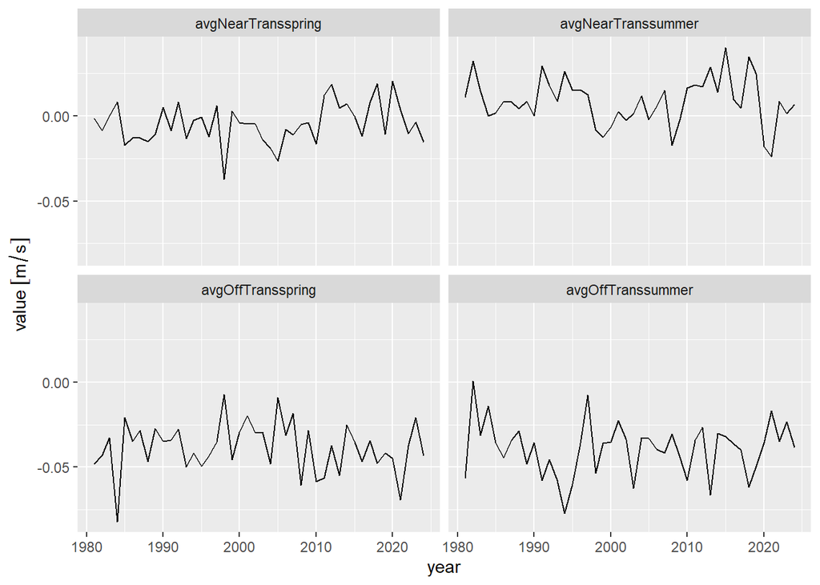

```r
transport %>% pivot_longer(cols = -year) %>%
  ggplot(aes(x = year, y = value)) +
    geom_line() +
    facet_wrap(~name)
```

```r
# create proportional offshore:nearshore flow index
#!!Note: this isn't a continuous metric:
#  - switches to negative when nearshore flow has net positive (northward) direction
#  - also only works if offshore flow is negative (southward)
#  - Sqrt transform removes some years with high positive northward flow
transport <- transport %>% mutate(sprRelOffTrans = as.numeric(avgOffTransspring/(avgOffTransspring+avgNearTransspring)),
                                  sumRelOffTrans = as.numeric(avgOffTranssummer/(avgOffTranssummer+avgNearTranssummer)),
                                  sprRelOffTrans = sqrt(sprRelOffTrans), # deal with some of the skewness
                                  sumRelOffTrans = sqrt(sumRelOffTrans),
                                  sumRelOffTrans = case_when(is.nan(sumRelOffTrans) ~ 0,
                                                             TRUE ~ sumRelOffTrans))
```

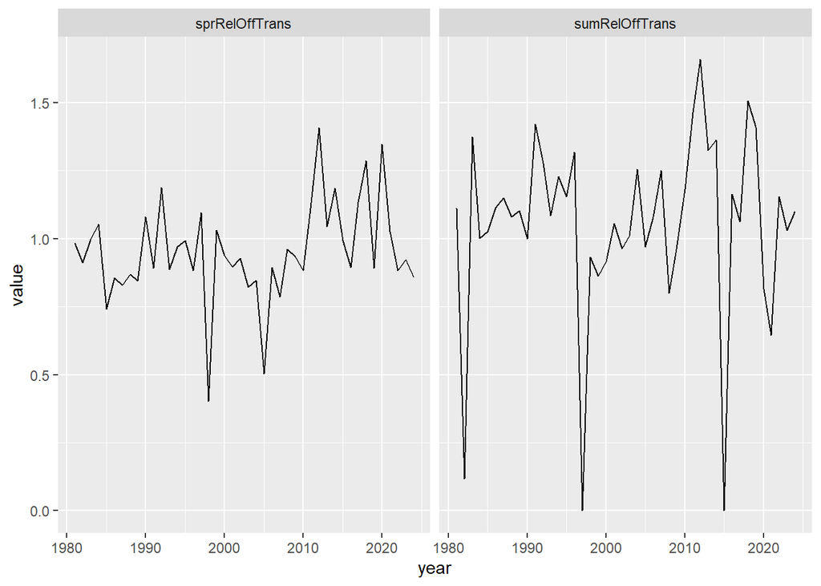

```r
transport %>% pivot_longer(cols = c(sprRelOffTrans, sumRelOffTrans)) %>%
  ggplot(aes(x = year, y = value)) +
    geom_line() +
    facet_wrap(~name)
```

# Larval indices

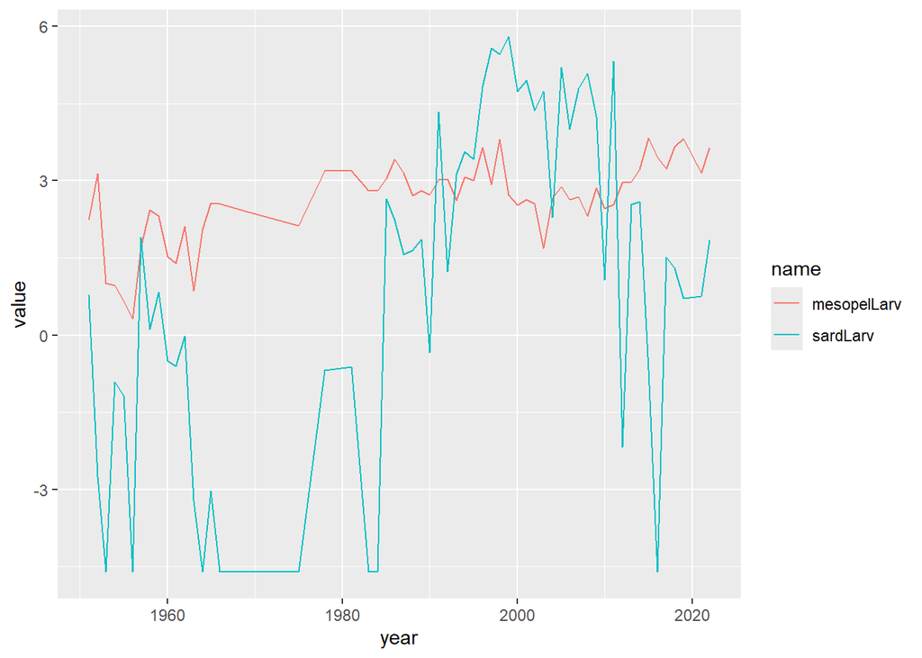

```r
load(file = paste0(datPath,"sardineLarvalIndex.RData"))

yr.vec <- names(coef(sardLarv))
yr.vec <- as.numeric(str_extract(yr.vec, "\\d+"))
yr.vec <- c(1951, yr.vec[which(yr.vec > 1900)])
indxGAM <- data.frame(year = yr.vec,
                      sardGAMcoef = as.vector(coef(sardLarv))[1:length(yr.vec)])
indxGAM$sardLarv <- coef(sardLarv)[1]
indxGAM <- indxGAM %>% mutate(sardLarv = sardLarv + c(0, sardGAMcoef[2:length(yr.vec)]),
                              # need to truncate zeros
                              sardLarv = case_when(sardLarv < log(0.01) ~ log(0.01),
                                                   TRUE ~ sardLarv))

load(file = paste0(datPath, "soMesopelLarvalIndex.RData"))
indxGAM$mesopelLarv <- coef(mesopelLarv)[1]
indxGAM$mesopelGAMcoef <- as.vector(coef(mesopelLarv))[1:length(yr.vec)]
indxGAM <- indxGAM %>% mutate(mesopelLarv = mesopelLarv + c(0, mesopelGAMcoef[2:length(yr.vec)]))

indxGAM %>% select(year, sardLarv, mesopelLarv) %>%
  pivot_longer(cols = -year) %>%
  ggplot(aes(x = year, y = value, color = name)) +
  geom_line()
```